# Task 1: Data Understanding

### 3.5 Cross-Validation

```python
from imblearn.pipeline import Pipeline
from sklearn.model_selection import cross_val_score

# Create a pipeline
pipeline = Pipeline([
    ('smote', SMOTE(random_state=42)),
    ('xgb', XGBClassifier(random_state=42))
])

# Perform 5-fold cross-validation using F1 score as the evaluation metric
scores = cross_val_score(pipeline, X_train, y_train, scoring='f1', cv=5)

# Print the F1 scores for each fold, along with the mean and standard deviation
print(f"Cross-Validation F1 Scores: {scores}")
print(f"Mean F1: {scores.mean():.3f}, Std: {scores.std():.3f}")
```

```
Cross-Validation F1 Scores: [0.78821879 0.80407596 0.78302337 0.79413157 0.80183908]
Mean F1: 0.794, Std: 0.008
```

- To achieve a more robust evaluation of model performance, a pipeline including SMOTE oversampling was used, followed by 5-fold cross-validation on the training set.
- The average F1 score was 0.794 with a standard deviation of 0.008, indicating stable and consistent performance.
- These results suggest that the model performs reliably across different data subsets, demonstrating good generalization ability and effectively balancing precision and recall, making it well-suited for diabetes prediction tasks.

### 3.6 Final Model Selection and Test Set Evaluation:

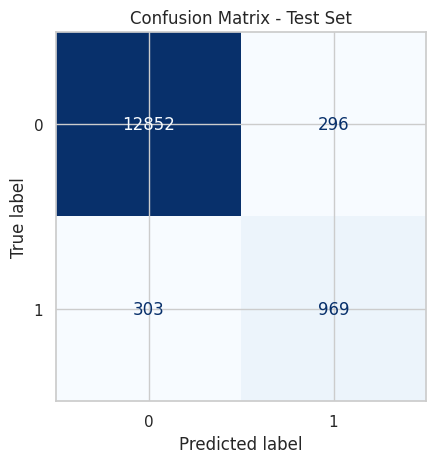

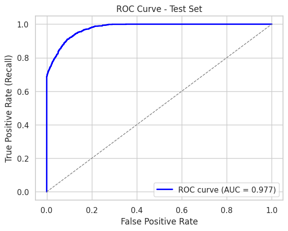

```
XGBoost Tuned Performance on Test Set (Threshold = 0.41):
  Test F1: 0.764
  Test Precision: 0.766
  Test Recall: 0.762
  Test ROC-AUC: 0.977
```

```python
from sklearn.metrics import roc_curve, auc, confusion_matrix, ConfusionMatrixDisplay

# Separate features and target variable from the test dataset
X_test = test_df.drop('diabetes', axis=1)
y_test = test_df['diabetes']

# Predict probabilities for the positive class using the best tuned model
y_test_proba = best_model.predict_proba(X_test)[:, 1]

# Apply the decision threshold of 0.41 to get binary predictions
y_test_pred = (y_test_proba >= 0.41).astype(int)

# Calculate evaluation metrics
test_f1 = f1_score(y_test, y_test_pred)
test_precision = precision_score(y_test, y_test_pred)
test_recall = recall_score(y_test, y_test_pred)
test_roc_auc = roc_auc_score(y_test, y_test_proba)

# Generate and display the confusion matrix
cm = confusion_matrix(y_test, y_test_pred)
disp = ConfusionMatrixDisplay(confusion_matrix=cm, display_labels=best_model.classes_)
disp.plot(cmap=plt.cm.Blues, colorbar=False)
plt.title('Confusion Matrix - Test Set')
plt.show()

# Plot ROC curve for the test set
fpr, tpr, _ = roc_curve(y_test, y_test_proba)
roc_auc = auc(fpr, tpr)
plt.figure()
plt.plot(fpr, tpr, color='blue', lw=2, label=f'ROC curve (AUC = {roc_auc:.3f})')
plt.plot([0, 1], [0, 1], color='gray', lw=1, linestyle='--')
plt.xlabel('False Positive Rate')
plt.ylabel('True Positive Rate (Recall)')
plt.title('ROC Curve - Test Set')
plt.legend(loc='lower right')
plt.grid(True)
plt.show()

# Print final performance metrics on the test set
print("\nXGBoost Tuned Performance on Test Set (Threshold = 0.41):")
print(f"  Test F1: {test_f1:.3f}")
print(f"  Test Precision: {test_precision:.3f}")
print(f"  Test Recall: {test_recall:.3f}")
print(f"  Test ROC-AUC: {test_roc_auc:.3f}")
```

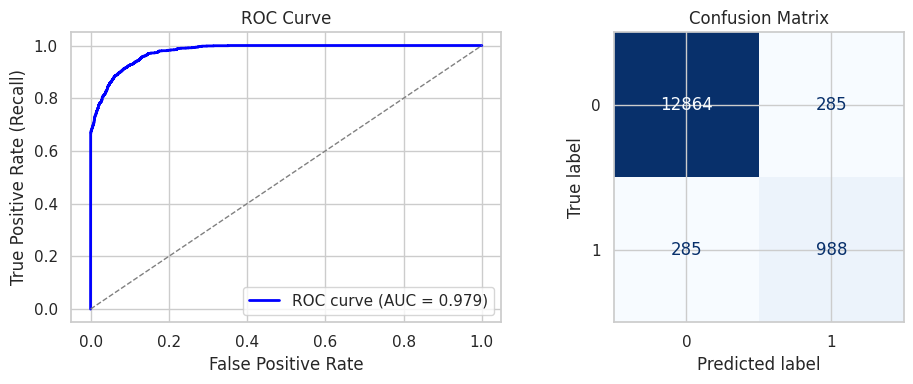

```
Classification Report:

              precision    recall  f1-score   support

           0       0.98      0.98      0.98     13149
           1       0.78      0.78      0.78      1273

    accuracy                           0.96     14422
   macro avg       0.88      0.88      0.88     14422
weighted avg       0.96      0.96      0.96     14422
```

```
['final_xgboost_model.pkl']
```

```python
# Predict probabilities for the positive class on the validation set using the best model
y_val_proba = best_model.predict_proba(X_val)[:, 1]
y_val_pred = (y_val_proba >= threshold).astype(int)

# Compute False Positive Rate (FPR), True Positive Rate (TPR) and thresholds for ROC curve
fpr, tpr, _ = roc_curve(y_val, y_val_proba)

# Calculate the Area Under the Curve (AUC) for the ROC
roc_auc = auc(fpr, tpr)

# Compute confusion matrix based on predicted classes and true labels
cm = confusion_matrix(y_val, y_val_pred)

# Create a figure with two subplots side by side
fig, axs = plt.subplots(1, 2, figsize=(10, 4))

# Plot the ROC curve in the first subplot
axs[0].plot(fpr, tpr, color='blue', lw=2, label=f'ROC curve (AUC = {roc_auc:.3f})')
axs[0].plot([0, 1], [0, 1], color='gray', lw=1, linestyle='--')
axs[0].set_xlabel('False Positive Rate')
axs[0].set_ylabel('True Positive Rate (Recall)')
axs[0].set_title('ROC Curve')
axs[0].legend(loc='lower right')
axs[0].grid(True)

# Display the confusion matrix in the second subplot
disp = ConfusionMatrixDisplay(confusion_matrix=cm, display_labels=best_model.classes_)
disp.plot(ax=axs[1], cmap=plt.cm.Blues, colorbar=False)
axs[1].set_title('Confusion Matrix')

plt.tight_layout()
plt.show()

# Print detailed classification report with precision, recall, f1-score, and support
print("Classification Report:\n")
print(classification_report(y_val, y_val_pred))

# Save the trained best model to a file for later use
import joblib
joblib.dump(best_model, 'final_xgboost_model.pkl')
```

Analysis of Validation Set Predictions After Retraining:

1. ROC Curve
- The AUC is 0.979, indicating that the model has a very strong ability to distinguish between diabetic and non-diabetic patients effectively.
2. Confusion Matrix
- The numbers of true negatives (TN) and true positives (TP) are both high, showing that the model correctly identifies the majority of samples.
- The false positives (FP) and false negatives (FN) are equal (both 285), which means that at the current threshold, the model balances misdiagnosis and missed diagnosis errors.
3. Classification Report
- The overall accuracy reaches 96%, demonstrating excellent performance.
- The model nearly perfectly identifies non-diabetic samples.
- For diabetic patients, the precision and recall are both 78%, indicating a good balance between avoiding missed diagnoses and reducing false alarms.

Summary：

- With this adjustment, the model shifted from having high precision but relatively low recall (base model) to a more balanced precision and recall (tuned model).
- If the priority is to minimize missed diagnoses, the tuned model is more suitable as it significantly reduces false negatives.
- If avoiding false positives is more important, the base model may be preferred due to its higher precision.

# Task 4: Reflection

## 4.3 Fairness and Ethical Considerations

- Positive Impacts:
  - Early detection can lead to timely interventions for high-risk individuals, reducing disease burden and unnecessary resource use.
  - Risk predictions can inform public health strategies and help optimize the allocation of medical resources.
- Potential Risks:
  - False positives may cause unnecessary anxiety or lead to unneeded tests and costs. False negatives may delay diagnosis and treatment, increasing the likelihood of serious complications.
  - Even with anonymized data, there are privacy risks; robust data protection and regulatory compliance are critical.
  - If training data lacks demographic diversity, the model may underperform for underrepresented groups, leading to inequitable healthcare outcomes.
  - Any real-world deployment must be guided by clinical judgment, with regular audits to monitor fairness and bias, ensuring the model remains safe, transparent, and equitable across populations.

## 4.4 Model Interpretability

XGBoost is a powerful black-box model whose internal decision-making process is not inherently transparent to humans. However, in the healthcare domain, predictive accuracy alone is not sufficient—both clinicians and patients need to understand why the model makes a particular prediction.

- To build trust and use the model as a reliable decision support tool, doctors need to understand the reasoning behind predictions. This enables them to validate and integrate model outputs into clinical workflows more responsibly.
- An interpretable model allows physicians to communicate risk factors and prediction rationale more clearly, helping patients understand their diabetes risk and engage in shared decision-making regarding prevention or treatment.

Improving interpretability can thus enhance model adoption, trust, and ethical transparency in real-world healthcare settings.

## 4.5 Limitations and Future Work

- Data Limitations:
  - The current dataset lacks comprehensive features such as genetic predispositions, physical activity, diet, and lifestyle habits — all of which play important roles in diabetes risk.
  - Diabetes is influenced by socioeconomic and environmental factors that are not captured here. This may introduce biases or reduce model fairness.
  - Future work should use diverse, representative datasets, and evaluate model performance across subgroups to ensure fairness and inclusiveness.
- Model Limitations:
  - Despite the use of oversampling techniques like SMOTE, class imbalance remains a challenge. Future work could explore more advanced data balancing methods to mitigate this issue further.
  - The current model performs static, point-in-time predictions and does not account for changes in a patient's health status over time. Future models could incorporate time-series data, enabling the prediction of disease progression evolution over time.
- Application Limitations:
  - This project is based on a public dataset and has not been validated in real-world clinical settings.
  - For the model to be clinically useful, it must undergo external validation, be compared against expert medical judgment, and be assessed for reliability, safety, and utility in operational healthcare environments.

```python
!jupyter nbconvert --to html '/content/drive/My Drive/Colab Notebooks/24200045_Diabetes_Prediction.ipynb'
```

```
[NbConvertApp] Converting notebook /content/drive/My Drive/Colab Notebooks/Diabetes_Prediction.ipynb to html
[NbConvertApp] WARNING | Alternative text is missing on 8 image(s).
[NbConvertApp] Writing 1188418 bytes to /content/drive/My Drive/Colab Notebooks/Diabetes_Prediction.html
```

```python
# files.download('final_xgboost_model.pkl')
```

```python
# files.download("train.csv")
# files.download("valid.csv")
# files.download("test.csv")
```

```python
# !pip freeze > requirements.txt
```

```python
# files.download('requirements.txt')
```